# Chapter 5 Graph Tables, Add Labels, Make Notes

```r
library(dplyr)
library(tibble)
library(ggplot2)
library(scales)
library(socviz)
library(forcats)
library(ggrepel)
```

Using the package ‘dplyr’ to get data into shape before using ggplot. Expand the number of geom_’s and how to choose among them. Learn more about scale, guide, and theme functions

Doing the same thing: 1. Define a set of tidy data. 2. Mapping of variables to aesthetic elements. 3. Select a particular type of graph (geom_)

## 5.1 Use pipes to summarize data

Using dplyr package and socviz::gss_sm dataset build a summary table with percentages of religious preferences grouped within region.

The main functions to use from dplyr package: group_by(), filter(), select(), mutate(), summarize().

```r
glimpse(socviz::gss_sm)
```

```
Observations: 2,867
Variables: 32
$ year        <dbl> 2016, 2016, 2016, 2016, 2016, 2016, 2016, 2016, 2016, 2016, 2016, 2016, 2016, 2016, 201...
$ id          <dbl> 1, 2, 3, 4, 5, 6, 7, 8, 9, 10, 11, 12, 13, 14, 15, 16, 17, 18, 19, 20, 21, 22, 23, 24, ...
$ ballot      <dbl> 1, 2, 3, 1, 3, 2, 1, 3, 1, 3, 2, 1, 2, 3, 2, 3, 3, 2, 2, 1, 2, 3, 2, 3, 3, 2, 1, 2, 2, ...
$ age         <dbl> 47, 61, 72, 43, 55, 53, 50, 23, 45, 71, 33, 86, 32, 60, 76, 33, 56, 62, 31, 43, 58, 32,...
$ childs      <dbl> 3, 0, 2, 4, 2, 2, 2, 3, 3, 4, 5, 4, 3, 5, 7, 2, 6, 5, 0, 2, 0, 3, 2, 2, 2, 8, 2, 0, 2, ...
$ sibs        <dbl> 2, 3, 3, 3, 2, 2, 2, 6, 5, 1, 4, 4, 3, 6, 0, 1, 3, 8, 2, 0, 1, 4, 2, 2, 2, 7, 1, 0, 1, ...
$ degree      <fct> Bachelor, High School, Bachelor, High School, Graduate, Junior College, High School, Hi...
$ race        <fct> White, White, White, White, White, White, White, Other, Black, White, Black, White, Bla...
$ sex         <fct> Male, Male, Male, Female, Female, Female, Male, Female, Male, Male, Female, Female, Mal...
$ region      <fct> New England, New England, New England, New England, New England, New England, New Engla...
$ income16    <fct> $170000 or over, $50000 to 59999, $75000 to $89999, $170000 or over, $170000 or over, $...
$ relig       <fct> None, None, Catholic, Catholic, None, None, None, Catholic, Protestant, None, Protestan...
$ marital     <fct> Married, Never Married, Married, Married, Married, Married, Married, Married, Married, ...
```

[output cut: 19 more lines]

Note: there are some ‘NA’ or missing values in the ‘religion’ factor:

```r
sum(is.na(gss_sm$religion))
```

```
[1] 18
```

So using forcats::fct_explicit_na() function, give missing values an explicit factor level, ensuring that they appear in summaries and on plots.

```r
gss_sm_missing <- gss_sm %>%
  mutate(
    religion = forcats::fct_explicit_na(gss_sm$religion, na_level = "(Missing)")
  )
# check for NA's under religion again
sum(is.na(gss_sm_missing$religion))
```

```
[1] 0
```

```r
levels(gss_sm_missing$religion)
```

```
[1] "Protestant" "Catholic"   "Jewish"     "None"       "Other"      "(Missing)"
```

```r
(rel_by_region <- gss_sm_missing %>%
  group_by(bigregion, religion) %>%
  summarise(N = n()) %>%
  mutate(
    frac = N/sum(N),
    pct = round(frac * 100, 0)
  )
)
```

| bigregion | religion | N | frac | pct |
| --- | --- | --- | --- | --- |
| Northeast | Protestant | 158 | 0.323770492 | 32 |
| Northeast | Catholic | 162 | 0.331967213 | 33 |
| Northeast | Jewish | 27 | 0.055327869 | 6 |
| Northeast | None | 112 | 0.229508197 | 23 |
| Northeast | Other | 28 | 0.057377049 | 6 |
| Northeast | (Missing) | 1 | 0.002049180 | 0 |
| Midwest | Protestant | 325 | 0.467625899 | 47 |
| Midwest | Catholic | 172 | 0.247482014 | 25 |
| Midwest | Jewish | 3 | 0.004316547 | 0 |
| Midwest | None | 157 | 0.225899281 | 23 |

[output cut: 14 more lines]

Note that ‘summarise()’ retains the ‘bigregion’ and ‘religion’ variables; adds a new variable ‘N’ and drops all the other variables. ‘mutate()’ adds two new variables – ‘frac’ and ‘pct’.

Check that the percentages add up to 100% for each ‘bigregion’:

```r
(rel_by_region %>%
  group_by(bigregion) %>%
  summarize(
    total_pct = sum(pct)
  )
)
```

| bigregion | total_pct |
| --- | --- |
| Northeast | 100 |
| Midwest | 101 |
| South | 100 |
| West | 101 |

Since we are working directly with percentages, we can use ‘geom_col()’ instead of ‘geom_bar()’:

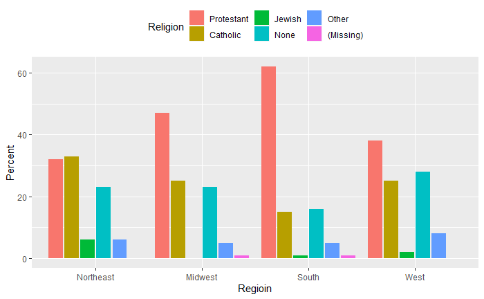

```r
ggplot(rel_by_region, aes(bigregion, pct, fill = religion)) +
  geom_col(position = "dodge2") +
  labs(
    x = "Regioin",
    y = "Percent",
    fill = "Religion"
  ) +
  theme(legend.position = "top")
```

Note: ‘dodge2’ adds padding = 0.1, whereas ‘dodge’ does not add padding among the bars. Can improve chart – above chart has too many bars – hard to compare bars. Use faceting to remove the ‘fill = religion’ legend and make the chart easier to read. With facetiing for ‘bigregion’, put ‘religion’ on the x axis and ‘pct’ on the y axis and then flip the axis’:

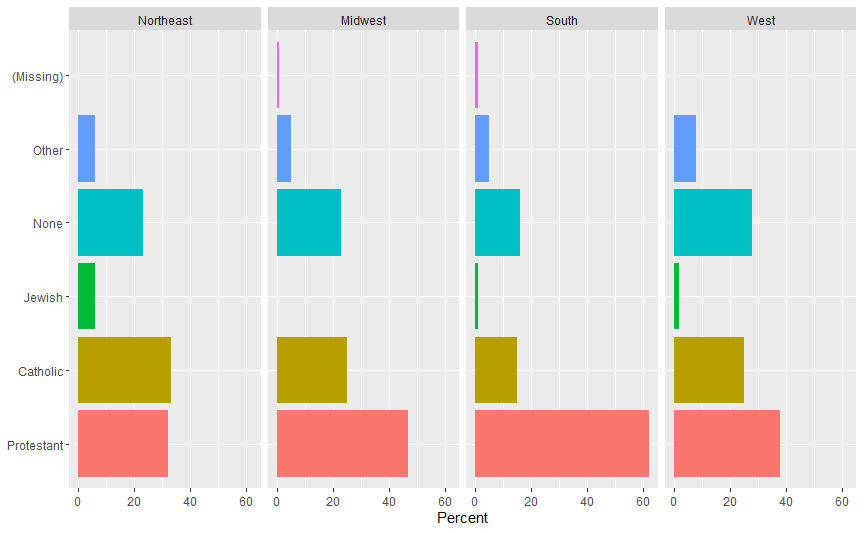

```r
ggplot(rel_by_region, aes(religion, pct, fill = religion)) +
  geom_col(position = "dodge2") +
  labs(x = NULL, y = "Percent") +
  guides(fill = FALSE) +
  coord_flip() +
  facet_grid(~bigregion)
```

## 5.2 Continuous variables by group or category

New dataset: ‘socviz::organdata’

```r
glimpse(socviz::organdata)
```

```
Observations: 238
Variables: 21
$ country          <chr> "Australia", "Australia", "Australia", "Australia", "Australia", "Australia", "Au...
$ year             <date> NA, 1991-01-01, 1992-01-01, 1993-01-01, 1994-01-01, 1995-01-01, 1996-01-01, 1997...
$ donors           <dbl> NA, 12.09, 12.35, 12.51, 10.25, 10.18, 10.59, 10.26, 10.48, 8.67, 10.23, 9.53, 10...
$ pop              <int> 17065, 17284, 17495, 17667, 17855, 18072, 18311, 18518, 18711, 18926, 19153, 1941...
$ pop_dens         <dbl> 0.2204433, 0.2232723, 0.2259980, 0.2282198, 0.2306484, 0.2334516, 0.2365389, 0.23...
$ gdp              <int> 16774, 17171, 17914, 18883, 19849, 21079, 21923, 22961, 24148, 25445, 26545, 2746...
$ gdp_lag          <int> 16591, 16774, 17171, 17914, 18883, 19849, 21079, 21923, 22961, 24148, 25445, 2654...
$ health           <dbl> 1300, 1379, 1455, 1540, 1626, 1737, 1846, 1948, 2077, 2231, 2379, 2504, 2629, 275...
$ health_lag       <dbl> 1224, 1300, 1379, 1455, 1540, 1626, 1737, 1846, 1948, 2077, 2231, 2379, 2504, 262...
$ pubhealth        <dbl> 4.8, 5.4, 5.4, 5.4, 5.4, 5.5, 5.6, 5.7, 5.9, 6.1, 6.2, 6.2, 6.2, NA, 5.2, 5.2, 5....
$ roads            <dbl> 136.59537, 122.25179, 112.83224, 110.54508, 107.98096, 111.60912, 107.58560, 95.4...
$ cerebvas         <int> 682, 647, 630, 611, 631, 592, 576, 525, 516, 493, 474, 449, 424, NA, 953, 942, 88...
$ assault          <int> 21, 19, 17, 18, 17, 16, 17, 17, 16, 15, 16, 15, 14, NA, 16, 12, 14, 13, 11, 10, 1...
$ external         <int> 444, 425, 406, 376, 387, 371, 395, 385, 410, 409, 393, 367, 341, NA, 614, 590, 54...
$ txp_pop          <dbl> 0.9375916, 0.9257116, 0.9145470, 0.9056433, 0.8961075, 0.8853475, 0.8737917, 0.86...
$ world            <chr> "Liberal", "Liberal", "Liberal", "Liberal", "Liberal", "Liberal", "Liberal", "Lib...
$ opt              <chr> "In", "In", "In", "In", "In", "In", "In", "In", "In", "In", "In", "In", "In", "In...
$ consent_law      <chr> "Informed", "Informed", "Informed", "Informed", "Informed", "Informed", "Informed...
$ consent_practice <chr> "Informed", "Informed", "Informed", "Informed", "Informed", "Informed", "Informed...
$ consistent       <chr> "Yes", "Yes", "Yes", "Yes", "Yes", "Yes", "Yes", "Yes", "Yes", "Yes", "Yes", "Yes...
$ ccode            <chr> "Oz", "Oz", "Oz", "Oz", "Oz", "Oz", "Oz", "Oz", "Oz", "Oz", "Oz", "Oz", "Oz", "Oz...
```

Plot ‘year’ by ‘donors’:

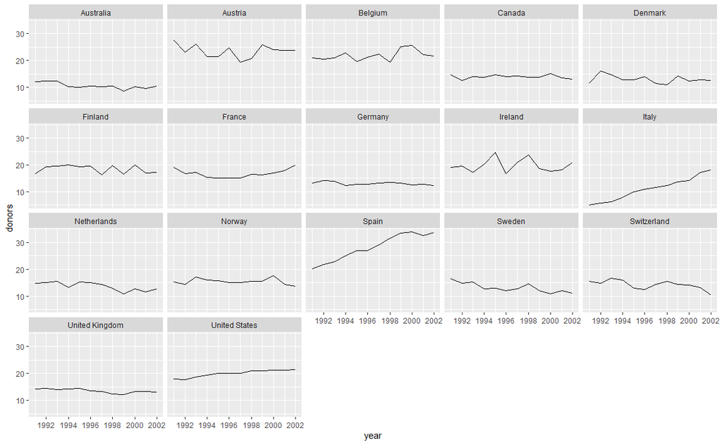

```r
ggplot(organdata, aes(year, donors)) +
  geom_line(aes(group = country)) +
  facet_wrap(~country)
```

Looking at country variation without looking at the yearly trend using geom_boxplot():

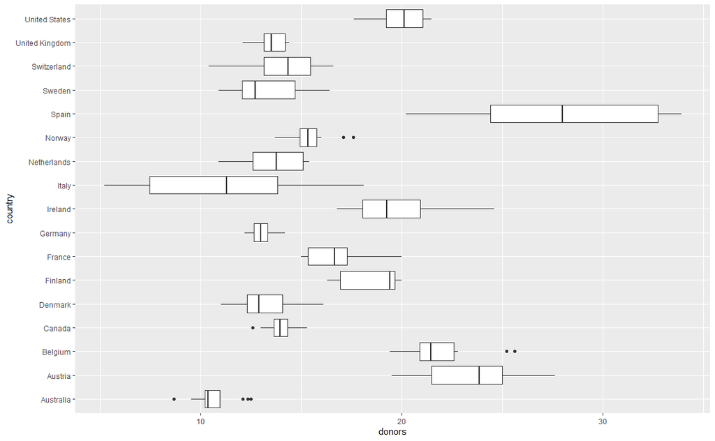

```r
ggplot(organdata, aes(country, donors)) +
  geom_boxplot() +
  coord_flip()
```

Reorder donations from high to low using reorder() function. reorder() takes two arguments: the varible to be reordered and the variable to base the reordering on:

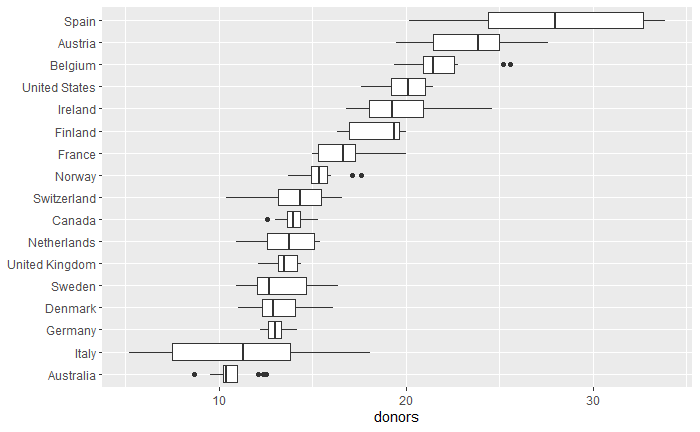

```r
ggplot(organdata, aes(x = reorder(country, donors, na.rm = TRUE), y = donors)) +
  geom_boxplot() +
  labs(x = NULL) +
  coord_flip()
```

geom_boxplot can accept a fill variable:

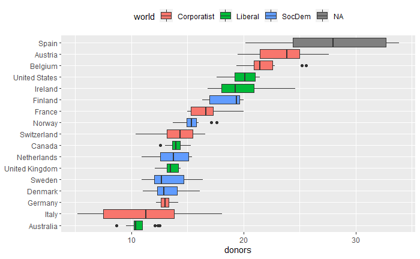

```r
ggplot(organdata, aes(x = reorder(country, donors, na.rm = TRUE), y = donors, fill = world)) +
  geom_boxplot() +
  labs(x = NULL) +
  coord_flip() +
  theme(legend.position = "top")
```

With the number of observations in each country small, we can geom_point() (or geom_jitter() for overlapped points) instead of using geom_boxplot():

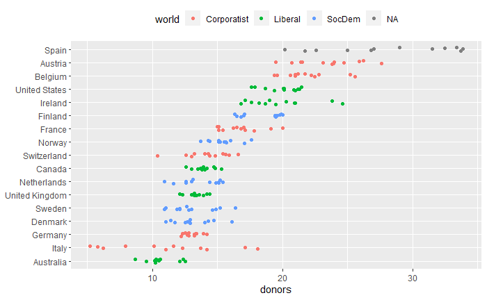

```r
ggplot(organdata, aes(x = reorder(country, donors, na.rm = TRUE), y = donors, color = world)) +
  geom_jitter(position = position_jitter(width = 0.15)) +
  labs(x = NULL) +
  coord_flip() +
  theme(legend.position = "top")
```

Grouping organdata by consent_law and country variables and summarizing with a number of statistics (using dplyr):

```r
(by_country <- organdata %>%
  group_by(consent_law, country) %>%
  summarize(
    donors_mean = mean(donors, na.rm = TRUE),
    donors_sd = sd(donors, na.rm = TRUE),
    gdp_mean = mean(gdp, na.rm = TRUE),
    health_mean = mean(health, na.rm = TRUE),
    roads_mean = mean(roads, na.rm = TRUE),
    cerebvas_mean = mean(cerebvas, na.rm = TRUE)

  )
)
```

| consent_law | country | donors_mean | donors_sd | gdp_mean | health_mean | roads_mean | cerebvas_mean |
| --- | --- | --- | --- | --- | --- | --- | --- |
| Informed | Australia | 10.63500 | 1.1428075 | 22178.54 | 1957.500 | 104.87573 | 557.6923 |
| Informed | Canada | 13.96667 | 0.7511607 | 23711.08 | 2271.929 | 109.26011 | 422.3846 |
| Informed | Denmark | 13.09167 | 1.4681208 | 23722.31 | 2054.071 | 101.63635 | 640.6923 |
| Informed | Germany | 13.04167 | 0.6111960 | 22163.23 | 2348.750 | 112.78873 | 706.7692 |
| Informed | Ireland | 19.79167 | 2.4784373 | 20824.38 | 1479.929 | 117.77424 | 704.6923 |
| Informed | Netherlands | 13.65833 | 1.5518074 | 23013.15 | 1992.786 | 76.09357 | 584.9231 |
| Informed | United Kingdom | 13.49167 | 0.7751344 | 21359.31 | 1561.214 | 67.92936 | 707.9231 |
| Informed | United States | 19.98167 | 1.3253667 | 29211.77 | 3988.286 | 155.16783 | 444.3846 |
| Presumed | Austria | 23.52500 | 2.4159037 | 23875.85 | 1875.357 | 149.86541 | 768.8462 |
| Presumed | Belgium | 21.90000 | 1.9357874 | 22499.62 | 1958.357 | 154.69504 | 593.8462 |

[output cut: 7 more lines]

An alternative where we summarize all the numeric variables:

```r
(by_country <- organdata %>%
  group_by(consent_law, country) %>%
  summarize_if(is.numeric, list(mean = mean, sd = sd), na.rm = TRUE) %>%
  ungroup()
)
```

| consent_law | country | donors_mean | pop_mean | pop_dens_mean | gdp_mean | gdp_lag_mean | health_mean | health_lag_mean | pubhealth_mean | roads_mean | cerebvas_mean | assault_mean | external_mean | txp_pop_mean | donors_sd | pop_sd | pop_dens_sd | gdp_sd | gdp_lag_sd | health_sd | health_lag_sd | pubhealth_sd | roads_sd | cerebvas_sd | assault_sd | external_sd | txp_pop_sd |
| --- | --- | --- | --- | --- | --- | --- | --- | --- | --- | --- | --- | --- | --- | --- | --- | --- | --- | --- | --- | --- | --- | --- | --- | --- | --- | --- | --- |
| Informed | Australia | 10.63500 | 18317.923 | 0.2366284 | 22178.54 | 21779.43 | 1957.500 | 1848.214 | 5.676923 | 104.87573 | 557.6923 | 16.769231 | 393.0000 | 0.8751195 | 1.1428075 | 830.89394 | 0.01073337 | 3958.506 | 4085.883 | 481.6276 | 460.0962 | 0.4245661 | 14.327316 | 82.69863 | 1.8327505 | 26.76440 | 0.039629946 |
| Informed | Canada | 13.96667 | 29607.923 | 0.2969520 | 23711.08 | 23353.07 | 2271.929 | 2163.429 | 6.676923 | 109.26011 | 422.3846 | 16.769231 | 410.6154 | 1.0485954 | 0.7511607 | 1192.74791 | 0.01196264 | 3965.847 | 4038.868 | 420.5751 | 379.1317 | 0.3919053 | 17.679258 | 38.46544 | 2.4547181 | 40.76873 | 0.042470126 |
| Informed | Denmark | 13.09167 | 5257.154 | 12.2004034 | 23722.31 | 23275.00 | 2054.071 | 1973.429 | 6.984615 | 101.63635 | 640.6923 | 12.230769 | 532.3846 | 0.7610332 | 1.4681208 | 80.60691 | 0.18706640 | 3895.685 | 4100.016 | 371.3614 | 357.7605 | 0.1519109 | 12.421001 | 46.27163 | 2.1273554 | 33.60441 | 0.011673046 |
| Informed | Germany | 13.04167 | 80254.846 | 22.4784601 | 22163.23 | 21938.36 | 2348.750 | 2256.250 | 8.142308 | 112.78873 | 706.7692 | 9.538462 | 391.3077 | 0.5508479 | 0.6111960 | 5157.63285 | 1.44459369 | 2501.344 | 2546.250 | 377.2275 | 383.7725 | 0.6244485 | 25.911094 | 126.03515 | 1.6641006 | 56.97424 | 0.043753449 |
| Informed | Ireland | 19.79167 | 3673.615 | 5.2278574 | 20824.38 | 20153.64 | 1479.929 | 1340.786 | 4.876923 | 117.77424 | 704.6923 | 8.538462 | 394.0000 | 0.8175829 | 2.4784373 | 131.59378 | 0.18726879 | 6669.580 | 6881.862 | 565.5526 | 482.4379 | 0.2862221 | 10.761587 | 87.20320 | 1.5607362 | 18.85471 | 0.028705994 |
| Informed | Netherlands | 13.65833 | 15547.692 | 37.4372557 | 23013.15 | 22553.64 | 1992.786 | 1884.857 | 5.700000 | 76.09357 | 584.9231 | 11.153846 | 285.8462 | 0.7078763 | 1.5518074 | 372.96434 | 0.89806005 | 3769.961 | 4009.418 | 417.0621 | 377.0521 | 0.3082207 | 9.930020 | 52.23259 | 1.3445045 | 18.62725 | 0.016975898 |
| Informed | United Kingdom | 13.49167 | 58186.692 | 23.9540127 | 21359.31 | 20962.50 | 1561.214 | 1463.500 | 5.761538 | 67.92936 | 707.9231 | 8.923077 | 287.9231 | 0.7047037 | 0.7751344 | 626.34567 | 0.25785092 | 3929.497 | 4056.793 | 405.0679 | 374.9447 | 0.3548203 | 10.467402 | 93.43577 | 1.6563785 | 15.14079 | 0.007572917 |
| Informed | United States | 19.98167 | 269329.769 | 2.7970428 | 29211.77 | 28699.43 | 3988.286 | 3760.429 | 5.776923 | 155.16783 | 444.3846 | 80.384615 | 530.0000 | 1.0193884 | 1.3253667 | 12544.86916 | 0.13028094 | 4571.160 | 4791.979 | 864.9320 | 807.5220 | 0.4621577 | 8.353810 | 16.04960 | 17.8724111 | 32.15587 | 0.047677193 |
| Presumed | Austria | 23.52500 | 7927.308 | 9.4530261 | 23875.85 | 23415.07 | 1875.357 | 1803.143 | 5.492308 | 149.86541 | 768.8462 | 10.923077 | 506.8462 | 0.6308434 | 2.4159037 | 109.19507 | 0.13021115 | 3342.889 | 3645.228 | 296.8980 | 316.8549 | 0.2660249 | 30.281692 | 119.64242 | 2.3259958 | 62.13540 | 0.008824909 |
| Presumed | Belgium | 21.90000 | 10153.308 | 30.6746456 | 22499.62 | 22095.93 | 1958.357 | 1862.429 | 6.188889 | 154.69504 | 593.8462 | 14.307692 | 541.6154 | 0.7880048 | 1.9357874 | 109.16378 | 0.32979994 | 3170.584 | 3400.119 | 405.1142 | 403.2977 | 0.2027588 | 20.556129 | 55.24920 | 3.6602508 | 22.87116 | 0.008483839 |

[output cut: 7 more lines]

Plot donors_mean by country with Donor and color of consent_law:

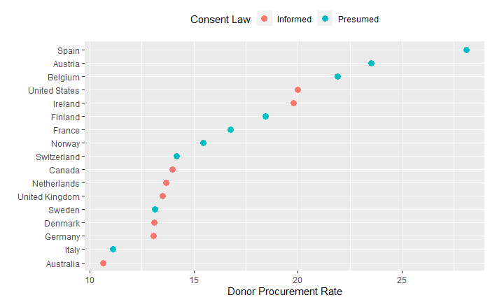

```r
ggplot(by_country, aes(donors_mean, y = reorder(country, donors_mean), color = consent_law)) +
  geom_point(size = 3) +
  labs(
    x = "Donor Procurement Rate",
    y = "",
    color = "Consent Law"
  ) +
  theme(legend.position = "top")
```

Cleveland dotplots are generally preferred to bar or column charts.  
Faceting by consent_law to remove the legend and color and scales = ‘free_y’:

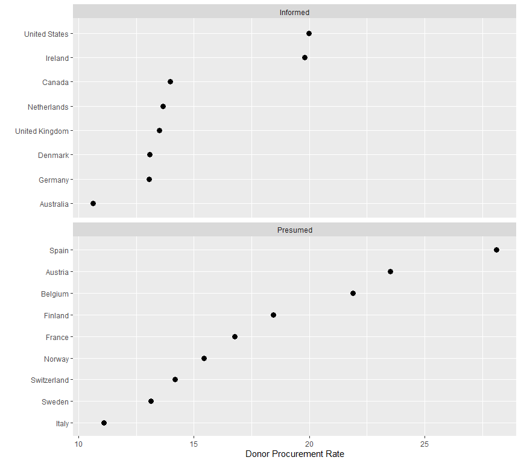

```r
ggplot(by_country, aes(donors_mean, y = reorder(country, donors_mean))) +
  geom_point(size = 3) +
  facet_wrap(~ consent_law, scales = "free_y", ncol = 1) +
   labs(
    x = "Donor Procurement Rate",
    y = ""
  )
```

Use geom_pointrange to plot sd around the mean:

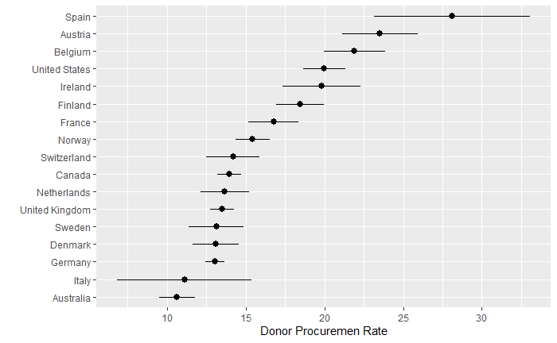

```r
ggplot(by_country, aes(x = reorder(country, donors_mean), y = donors_mean)) +
  geom_pointrange(aes(ymin = donors_mean - donors_sd, ymax = donors_mean + donors_sd)) +
  labs(x = "", y = "Donor Procuremen Rate") +
  coord_flip()
```

## 5.3 Plot text directly

Using geom_text().

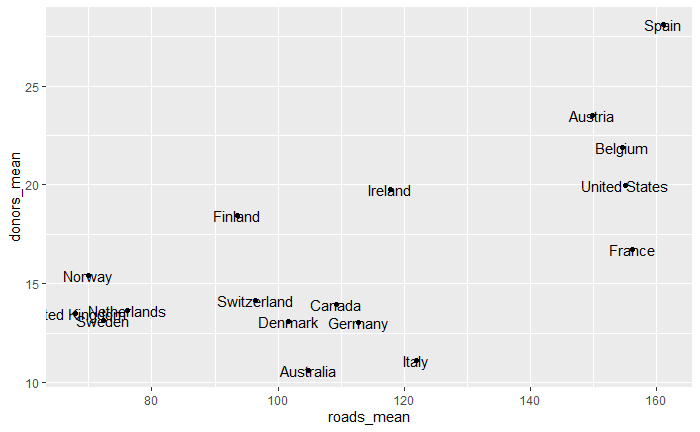

```r
ggplot(by_country, aes(roads_mean, donors_mean)) +
  geom_point() +
  geom_text(aes(label = country))
```

Adjust text position (hjust = 0 is left justify; hjust = 1 is right justify):

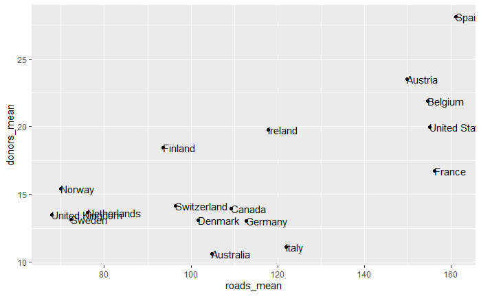

```r
ggplot(by_country, aes(roads_mean, donors_mean)) +
  geom_point() +
  geom_text(aes(label = country), hjust = 0)
```

Use package ggrepel for more flexible text labelling. Using a new dataset – socviz::elections_historic:

```r
socviz::elections_historic %>% select(2:7)
```

| year | winner | win_party | ec_pct | popular_pct | popular_margin |
| --- | --- | --- | --- | --- | --- |
| 1824 | John Quincy Adams | D.-R. | 0.3218 | 0.3092 | -0.1044 |
| 1828 | Andrew Jackson | Dem. | 0.6820 | 0.5593 | 0.1225 |
| 1832 | Andrew Jackson | Dem. | 0.7657 | 0.5474 | 0.1781 |
| 1836 | Martin Van Buren | Dem. | 0.5782 | 0.5079 | 0.1420 |
| 1840 | William Henry Harrison | Whig | 0.7959 | 0.5287 | 0.0605 |
| 1844 | James Polk | Dem. | 0.6182 | 0.4954 | 0.0145 |
| 1848 | Zachary Taylor | Whig | 0.5621 | 0.4728 | 0.0479 |
| 1852 | Franklin Pierce | Dem. | 0.8581 | 0.5083 | 0.0695 |
| 1856 | James Buchanan | Dem. | 0.5878 | 0.4529 | 0.1220 |
| 1860 | Abraham Lincoln | Rep. | 0.5941 | 0.3965 | 0.1013 |

[output cut: 39 more lines]

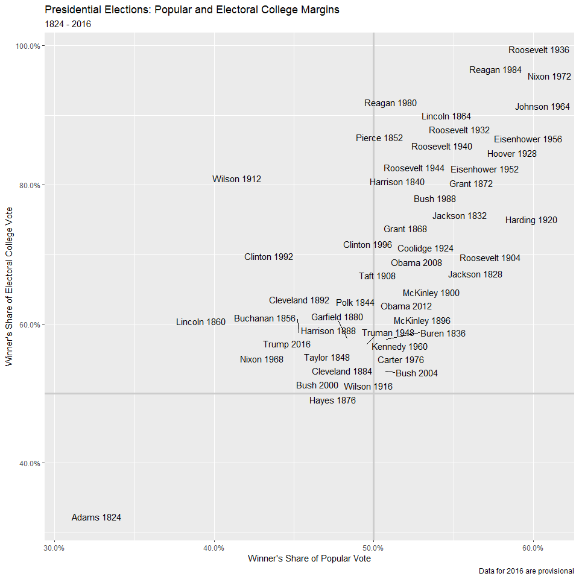

```r
p.title <- "Presidential Elections: Popular and Electoral College Margins"
p.subtitle <- "1824 - 2016"
p.caption <- "Data for 2016 are provisional"
x_label <- "Winner's Share of Popular Vote"
y_label <- "Winner's Share of Electoral College Vote"
ggplot(elections_historic, aes(popular_pct, ec_pct, label = winner_label)) +
  geom_hline(yintercept = 0.5, size = 1.4, color = "gray80") +
  geom_vline(xintercept = 0.5, size = 1.4, color = "gray80") +
  geom_text_repel() +
  scale_x_continuous(labels = scales::percent) +
  scale_y_continuous(labels = scales::percent) +
  labs(x = x_label, y = y_label, title = p.title, subtitle = p.subtitle, caption = p.caption)
```

## 5.4 Label outliers

Selecting points of interest.

[figure not shown]

```r
ggplot(by_country, aes(gdp_mean, health_mean)) +
  geom_point() +
  geom_text_repel(data = subset(by_country, gdp_mean > 25000 | health_mean < 1500 | country %in% "Belgium"), aes(label = country))
```

Creating a dummy variable:

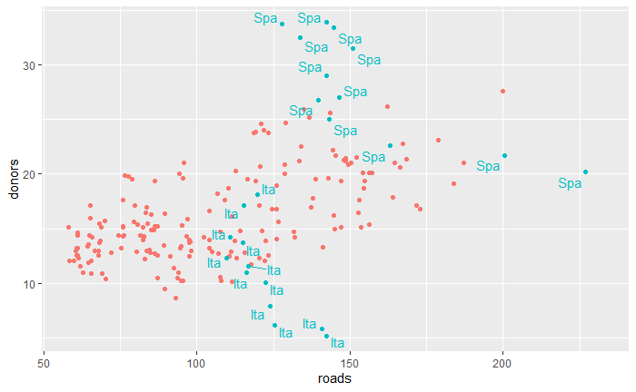

```r
organdata$ind <- organdata$ccode %in% c("Ita", "Spa") & organdata$year > 1998
ggplot(organdata, aes(x = roads, y = donors, color = ind)) +
  geom_point() +
  geom_text_repel(data = subset(organdata, ind), aes(label = ccode)) +
  guides(label = FALSE, color = FALSE)
```

## 5.5 Write and draw in the plot area

Using annotate() function.

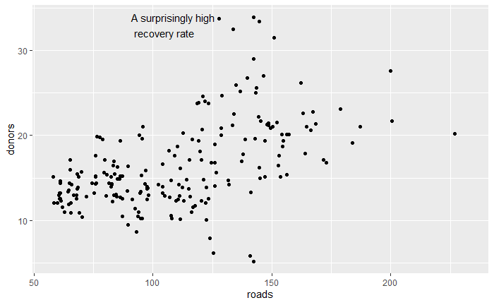

```r
ggplot(organdata, aes(roads, donors)) +
  geom_point() +
  annotate(geom = "text", x = 91, y = 33, label = "A surprisingly high \n recovery rate", hjust = 0)
```

## 5.6 Understanding scales, guides, themes

Set the aestheic to ‘shape’

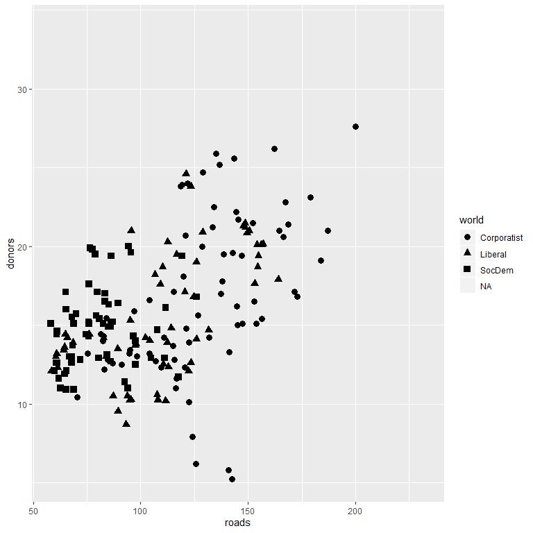

```r
ggplot(organdata, aes(roads, donors, shape = world)) +
  geom_point(size = 3)
```

Controlling the tick marks:

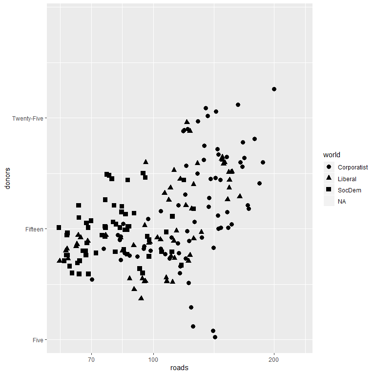

```r
ggplot(organdata, aes(roads, donors, shape = world)) +
  geom_point(size = 3) +
  scale_x_log10() +
  scale_y_continuous(breaks = c(5, 15, 25), labels = c("Five", "Fifteen", "Twenty-Five"))
```